# QL case Study: exploratory data analysis

Guanglai Li

6/5/2020

## Dependence of average success (“yes”) rate on individual features

The purpose of this analysis is to quickly visualize dependence of average outcome on a feature. It is not tuned for best visual effect.

### Reading data and check the outcome

Read the data and convert the outcome column *y* to integer, 0 for “no” and 1 for “yes”, so that the mean of the outcome is the average success rate.

```r
source("utilities.R")
dat <- fread("bank/bank-full.csv") %>%
    .[y == "yes", y := 1] %>%
    .[y == "no", y := 0] %>%
    .[, y := as.integer(y)]
```

The outcome is inbalanced, with far more failure than success. The average success rate is 0.1169848.

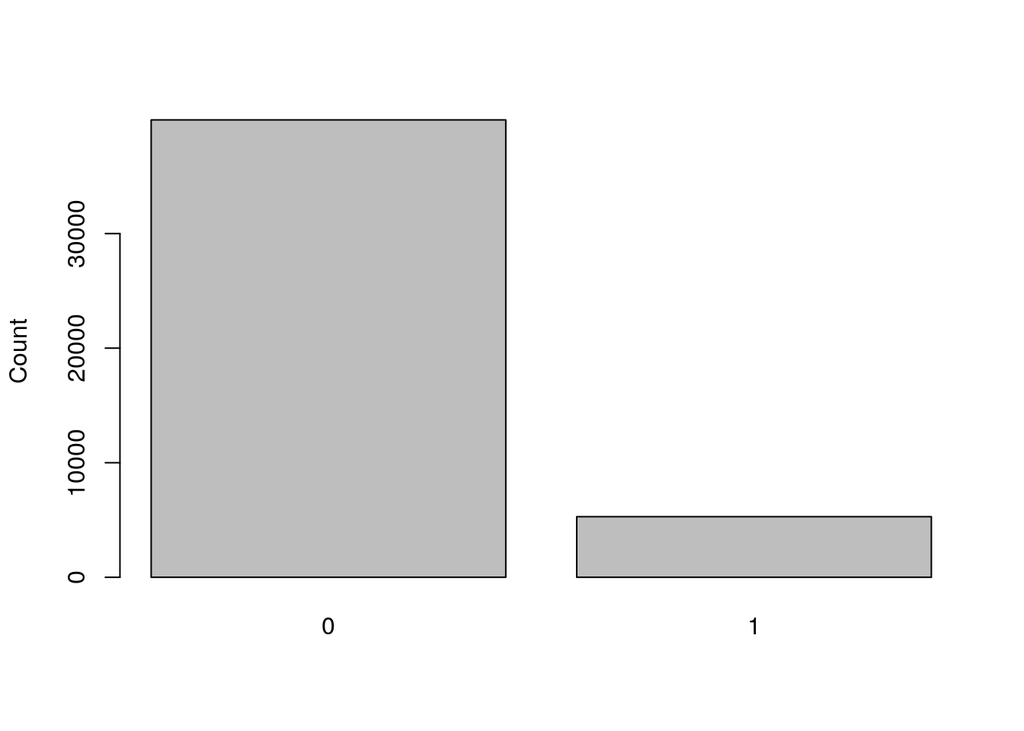

```r
barplot(table(dat$y), ylab = "Count")
```

The distribution of success is not homogeneous over time. The sparks may be the result of special campaign.

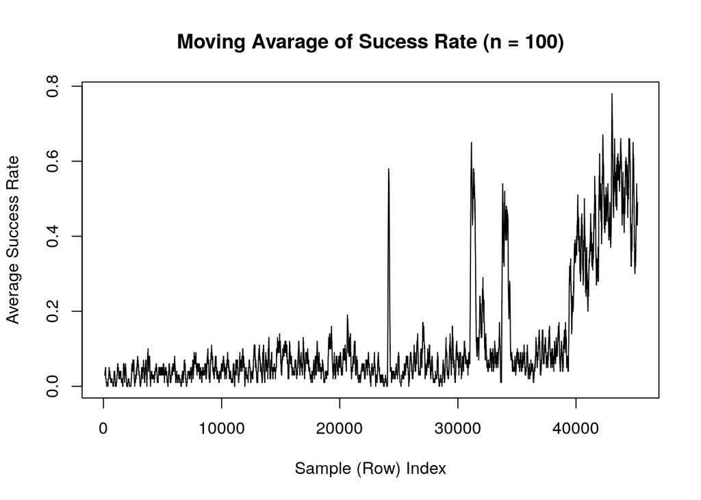

```r
# moving average
moving_avg <- function(x, n){
  ts <- stats::filter(x = x, filter = rep(1, n)/n, sides = 1)
  as.vector(ts)
}

dat[, mv_avg := moving_avg(y, 100)]
plot(1:nrow(dat), dat$mv_avg, type = "l",
     main = "Moving Avarage of Sucess Rate (n = 100)",
     xlab = "Sample (Row) Index",
     ylab = "Average Success Rate")
```

### Age

Age is skewed and the count have a quick drop after 60

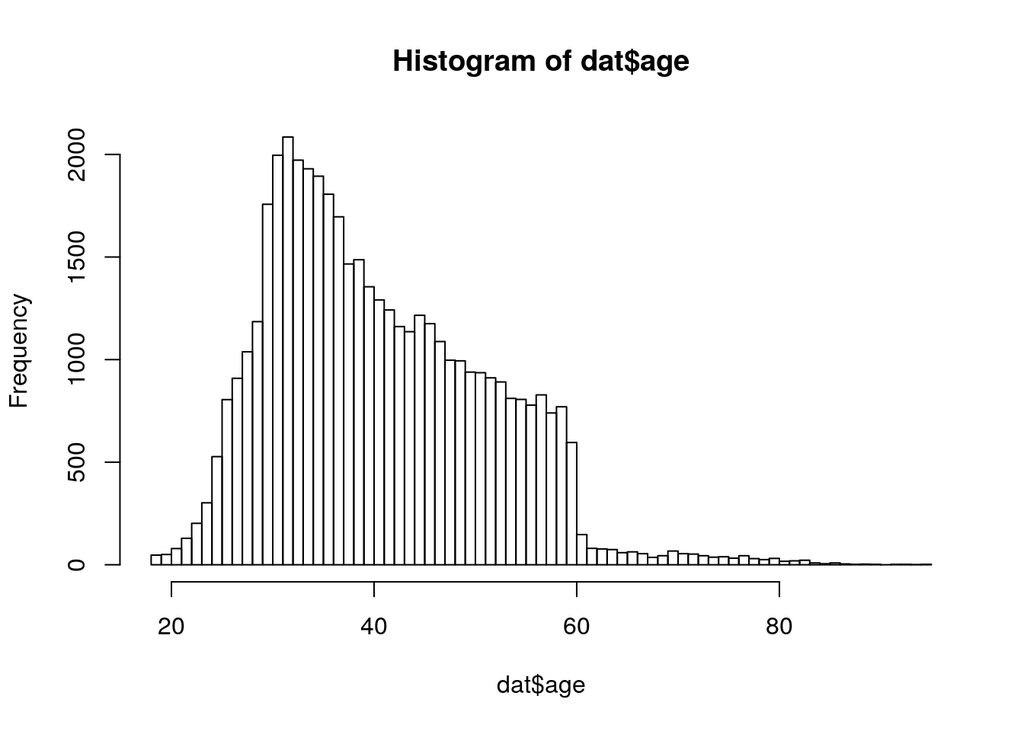

```r
hist(dat$age, breaks = 100)
```

The average outcome drop first with increasing age and then jumps after age = 60 (most of them are retired, which is a feature in job, so no need to create a new feature > 60). The buble size and numbers above bbbles indicate the number of samples.

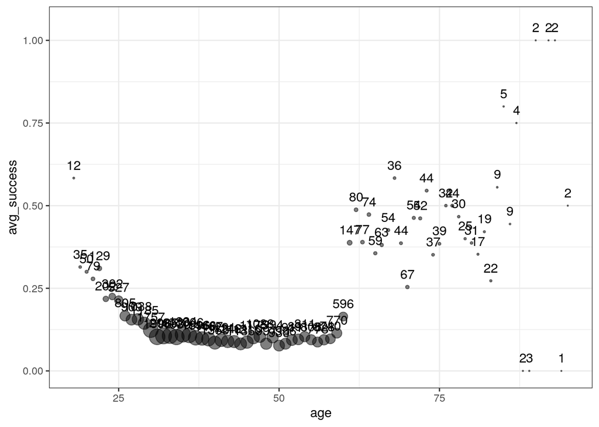

```r
plot_avg(dat, "age")
```

### job

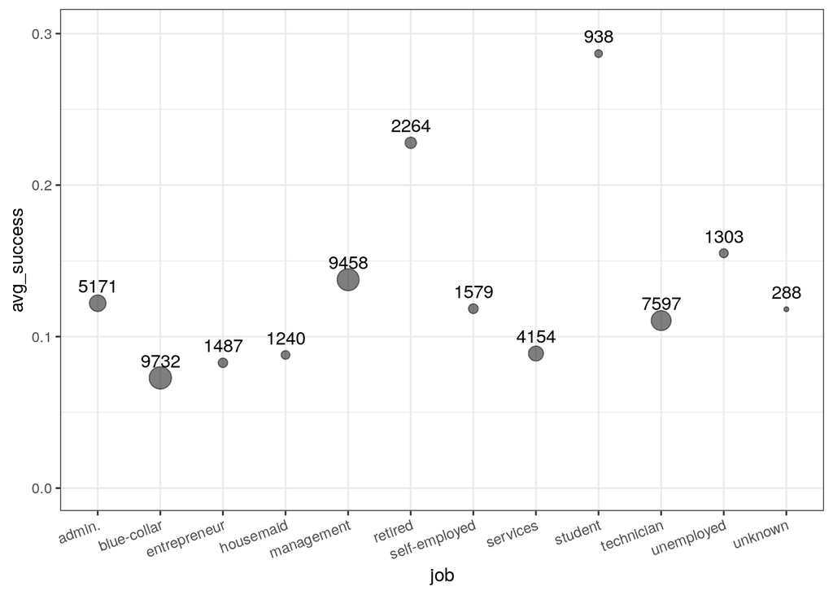

```r
plot_avg(dat, "job") + theme(axis.text.x = element_text(angle = 20, hjust = 1))
```

### marital

Singles have hight success rate.

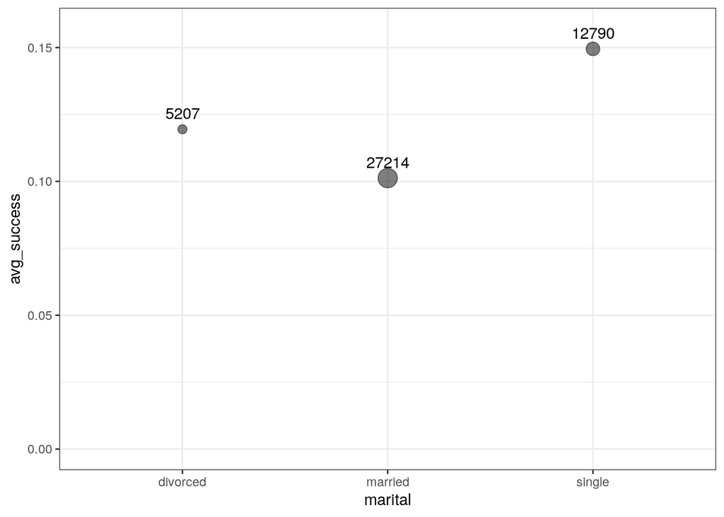

```r
plot_avg(dat, "marital")
```

### education

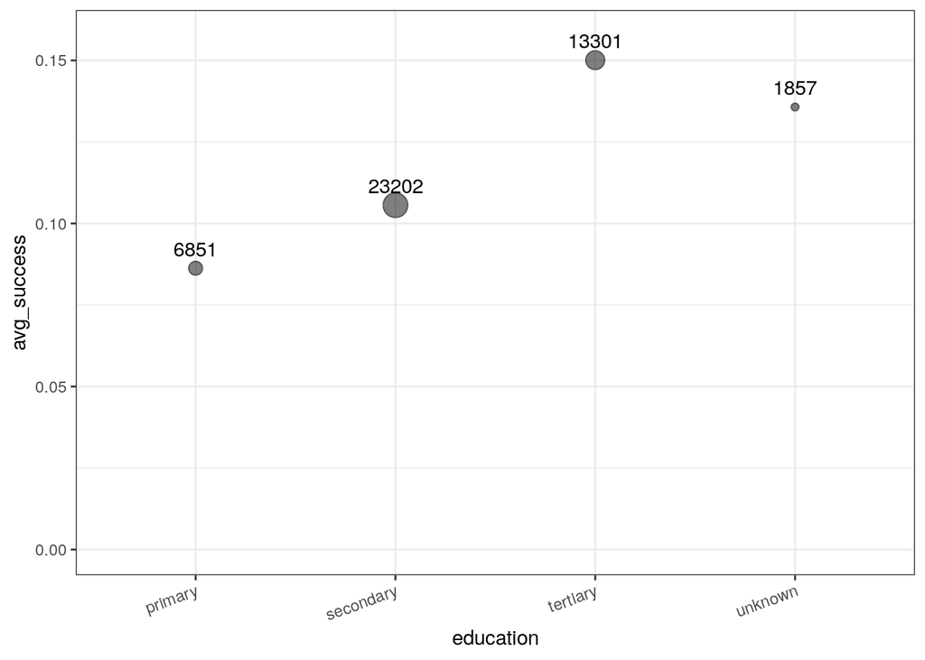

```r
plot_avg(dat, "education") + theme(axis.text.x = element_text(angle = 20, hjust = 1))
```

### credit default

Not supprising.

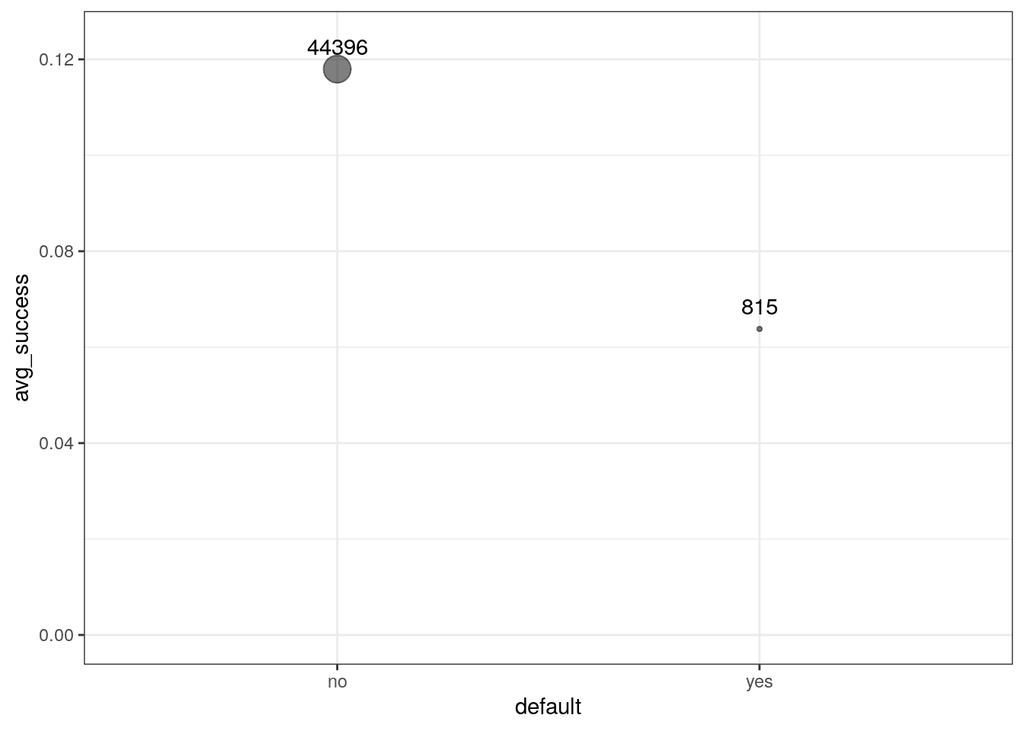

```r
plot_avg(dat, "default")
```

# balance

Skewed data. More money more likely to subscribe.

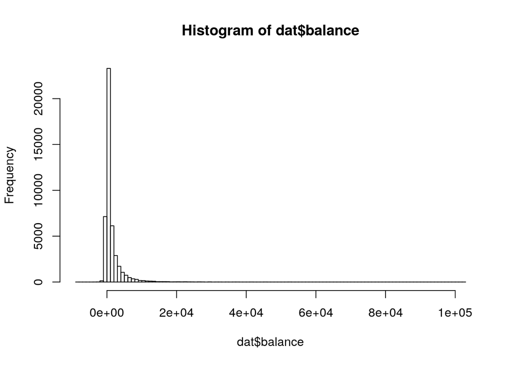

```r
hist(dat$balance, breaks = 100)
```

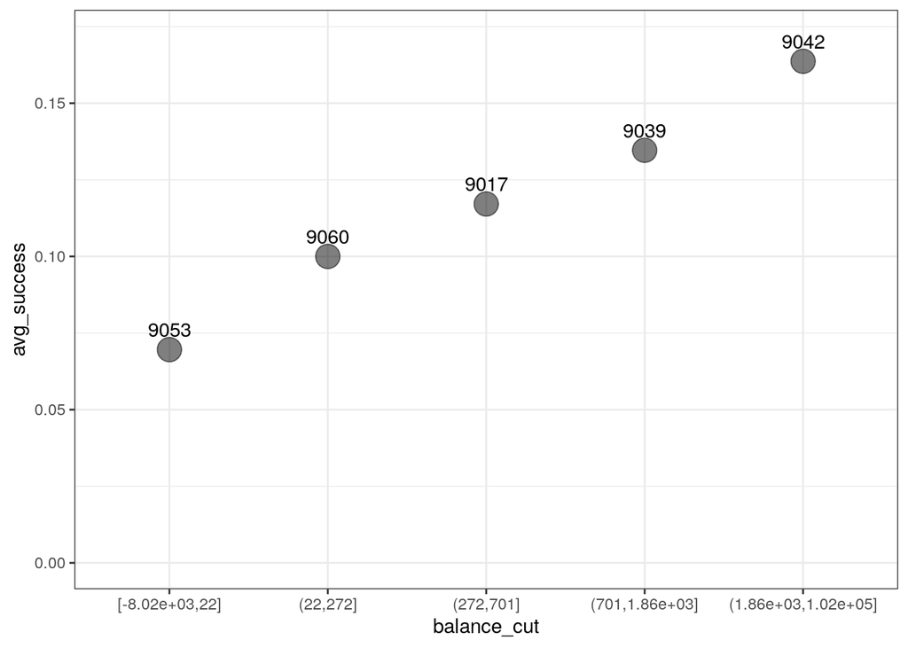

```r
dat$balance_cut <- ggplot2::cut_number(dat$balance, n = 5)
plot_avg(dat, "balance_cut")
```

### housing loan?

Loan free is good.

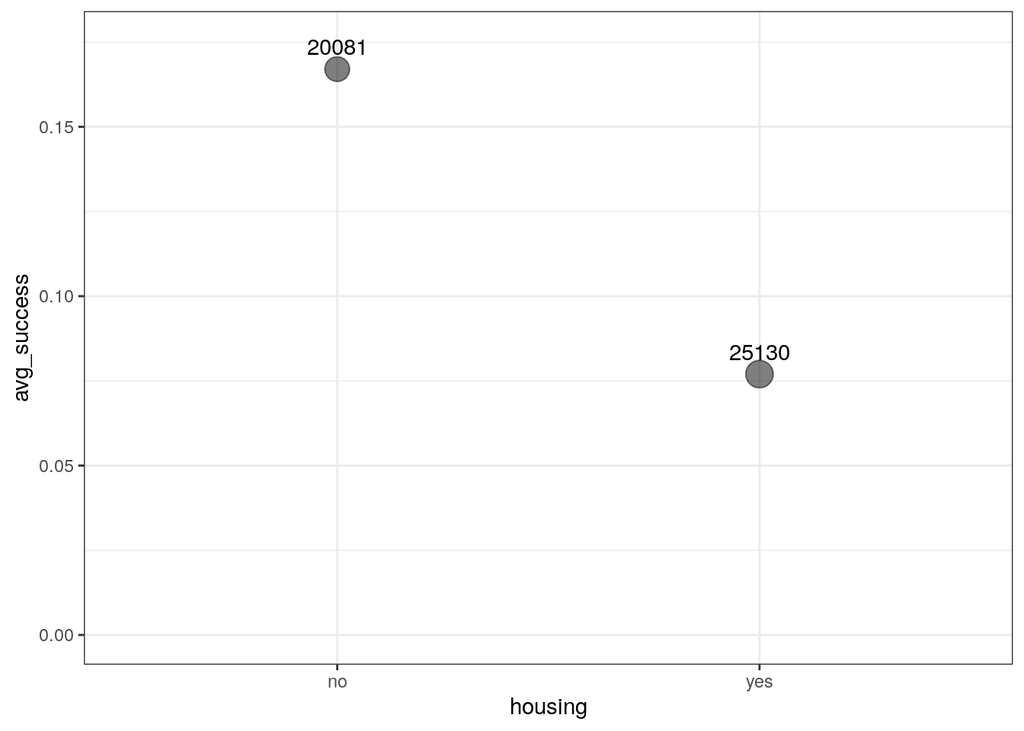

```r
plot_avg(dat, "housing")
```

### personal loan?

Good to have no debt.

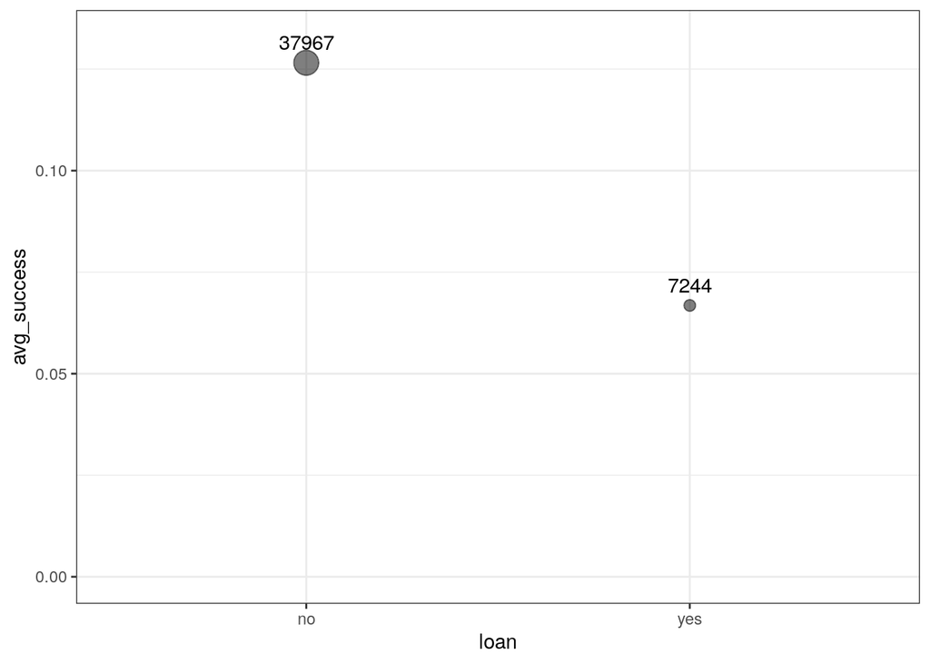

```r
plot_avg(dat, "loan")
```

# contact: cell phone or landline

Why unknown is so special?!

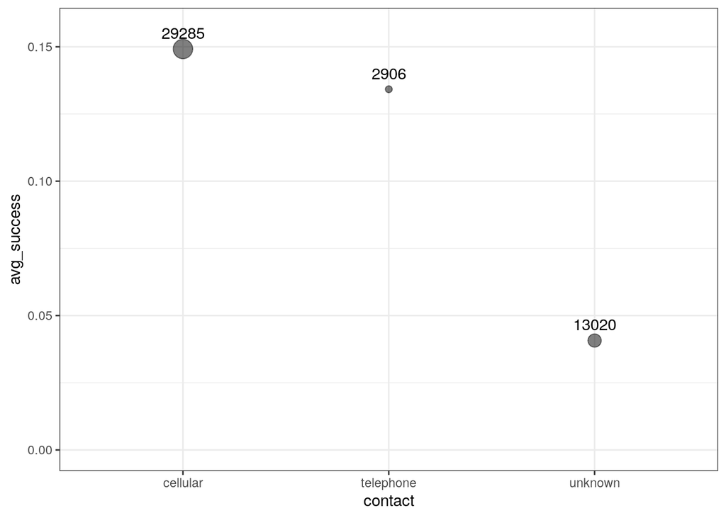

```r
plot_avg(dat, "contact")
```

### month

Four month with small sample number but high success rate. It is not going to be reproducible. Delete this feature.

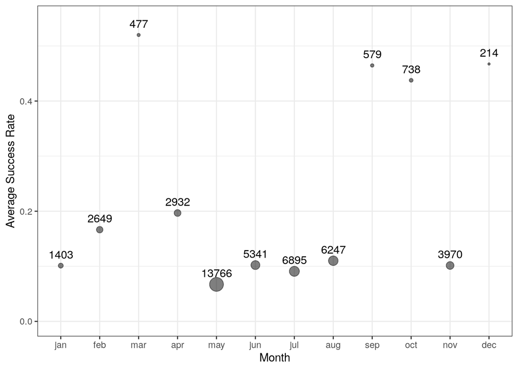

```r
dat$month = factor(dat$month,
                   levels = c("jan", "feb", "mar", "apr", "may", "jun", "jul",
                              "aug", "sep", "oct", "nov", "dec"))
plot_avg(dat, "month") +
  labs(x = "Month", y = "Average Success Rate")
```

### day

The first day is special but the sample number (322) is too low. Delete as it does not carry much information.

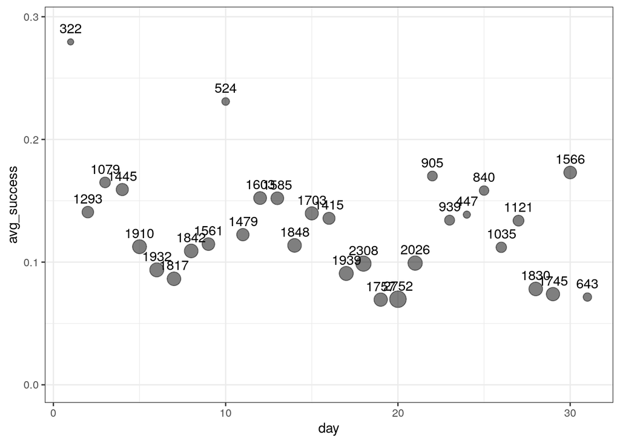

```r
plot_avg(dat, "day")
```

### number of contact in this campaign

Skewed but is really good indicator

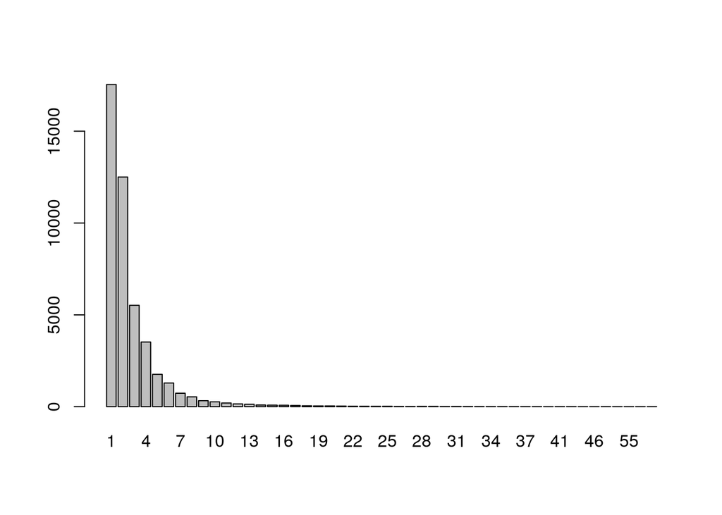

```r
barplot(table(dat$campaign))
```

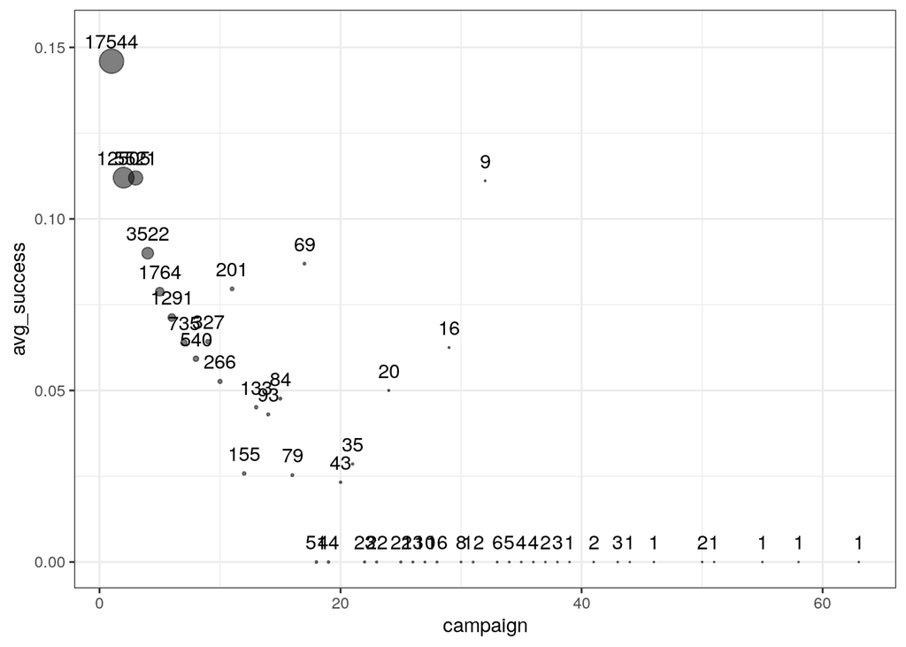

```r
plot_avg(dat, "campaign")
```

### days since last contact in a previous campaign

-1 means no contact in a previous campaign. For the small amount of sample with previous contact, it boosts success but no obvious trend with number of day, thus can be grouped together. Create a new feature to show with and without contact.

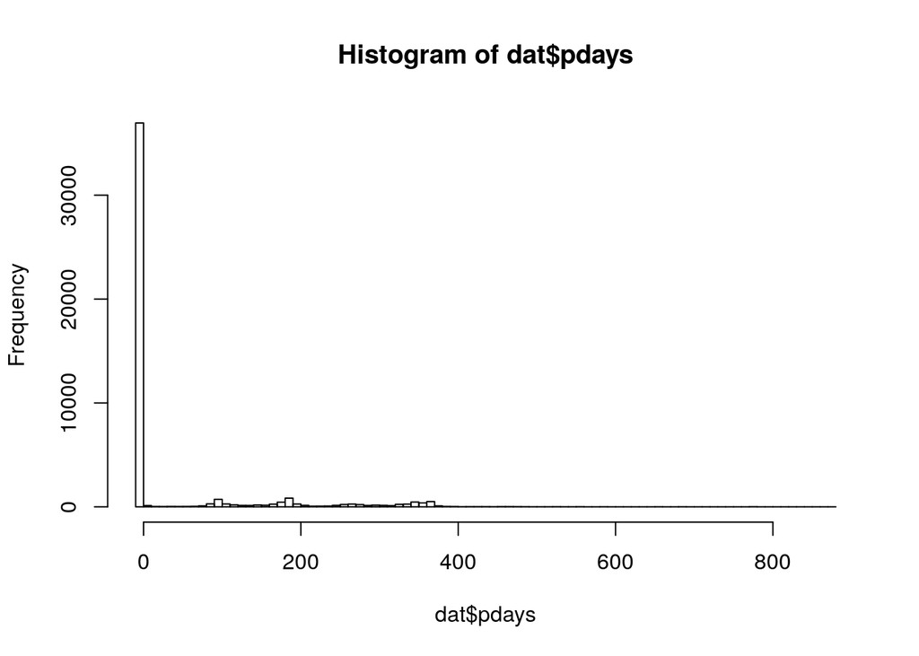

```r
hist(dat$pdays, breaks = 100)
```

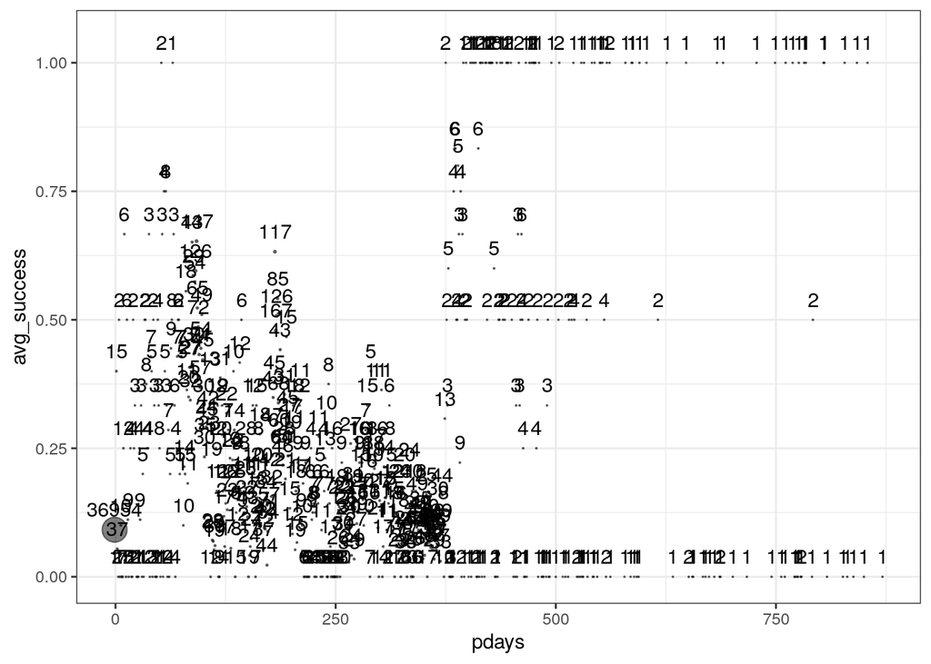

```r
plot_avg(dat, "pdays")
```

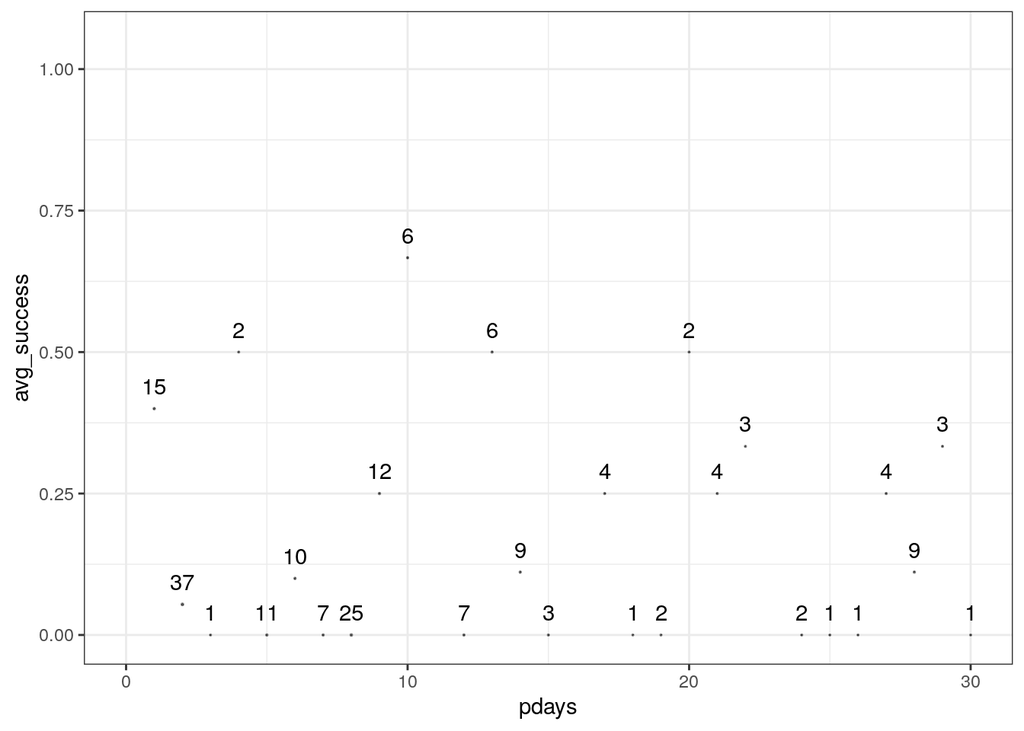

```r
plot_avg(dat, "pdays") + xlim(0, 30)
```

### number of contact in previous campaign

Highly correlated to pdays.

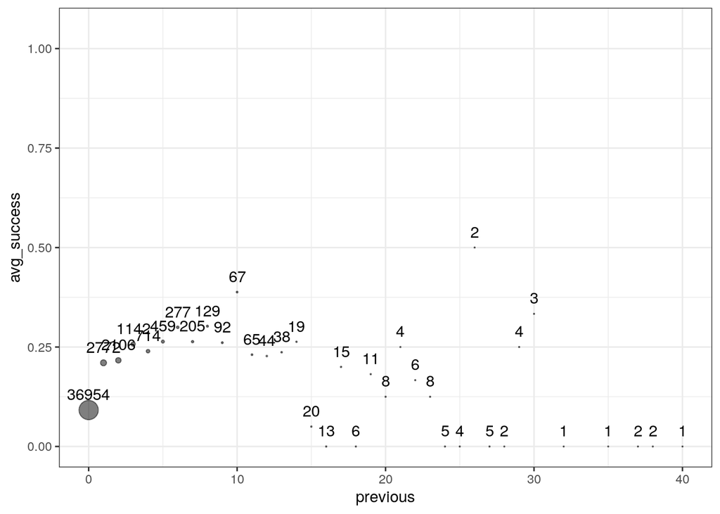

```r
plot_avg(dat, "previous") + xlim(0, 40)
```

### outcome of previous campaign

Success leads to success.

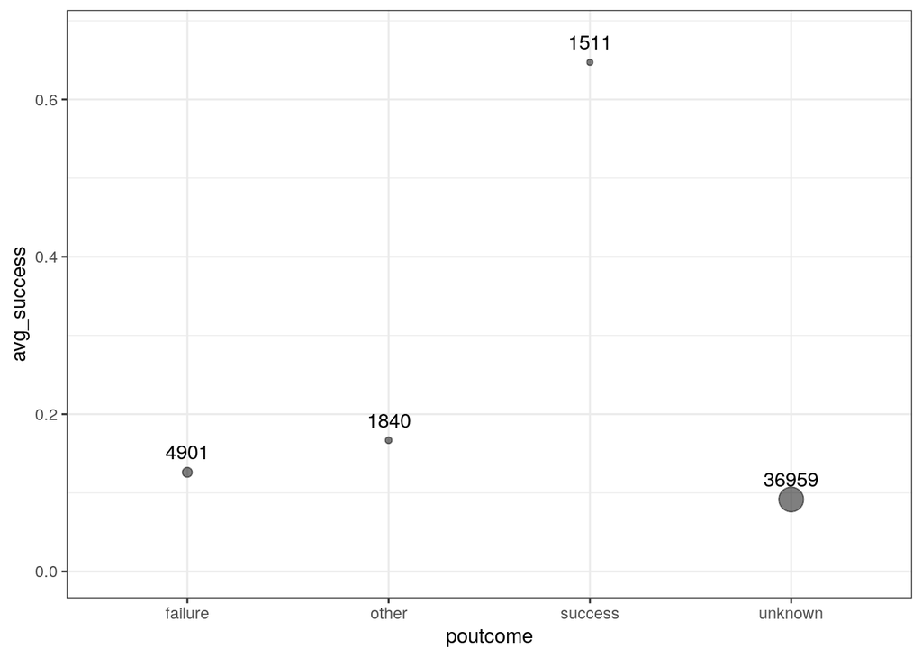

```r
plot_avg(dat, "poutcome")
```